# Pertemuan 2 MPDW

Cahyani Dyah Rofiana

2023-12-16

```r
library(dplyr)
library(TTR)
library(forecast)
library(lmtest) #untuk uji formal pendeteksian autokorelasi
library(orcutt) #untuk model regresi Cochrane-Orcutt
library(HoRM) #untuk model regresi Hildreth-Lu
```

## Input Data

```r
library(rio)
data <- import("https://raw.githubusercontent.com/CahyaniDyahRofiana/PraktikumUTSMPDW/main/Praktikum%202/fix.csv")
data
```

```
##          date   open   High    low  close   volume
## 1    1/4/2021  8.328  8.510  8.082  8.106  7901137
## 2    1/5/2021  8.142  8.730  8.134  8.730 11674727
## 3    1/6/2021  8.784  8.984  8.738  8.850 12401959
## 4    1/7/2021  8.886  8.950  8.580  8.882 17011938
## 5    1/8/2021  8.980  8.988  8.692  8.726 11807348
## 6   1/11/2021  8.664  8.726  8.540  8.636  5986272
## 7   1/12/2021  8.740  8.894  8.680  8.822  7688675
## 8   1/13/2021  8.860  8.922  8.694  8.702  5309109
## 9   1/14/2021  8.700  8.896  8.692  8.862  8655977
## 10  1/15/2021  8.820  8.856  8.522  8.652  8581202
## 11  1/18/2021  8.576  8.716  8.520  8.672  4430818
## 12  1/19/2021  8.710  8.780  8.622  8.632 16590328
## 13  1/20/2021  8.724  8.872  8.672  8.846  5764107
## 14  1/21/2021  8.860  8.876  8.560  8.570 11694014
```

[output cut: 156 more lines]

```r
View(data)
```

```r
#Membentuk objek time series
data.ts<-ts(data$close)
data.ts
```

```
## Time Series:
## Start = 1
## End = 170
## Frequency = 1
##   [1]  8.106  8.730  8.850  8.882  8.726  8.636  8.822  8.702  8.862  8.652
##  [11]  8.672  8.632  8.846  8.570  8.452  8.300  8.452  8.522  8.372  8.122
##  [21]  7.980  8.178  8.576  8.600  8.712  8.848  8.796  8.878  8.778  8.874
##  [31]  9.360  9.416  9.456  9.560  9.940 10.150 10.145 10.320 10.620 10.415
##  [41] 10.705 10.670 10.860 11.040 10.965 10.680 10.725 10.700 10.750 10.960
##  [51] 10.850 10.750 10.735 10.720 10.670 10.560 10.420 10.690 10.330 10.605
##  [61] 10.700 10.670 10.560 10.438 10.414 10.476 10.206 10.134 10.210 10.120
##  [71] 10.566 10.394 10.352 10.252  9.850 10.080 10.084 10.010 10.128 10.030
##  [81] 10.260 10.152  9.938 10.238 10.498 10.824 10.800 10.802 10.916 10.716
##  [91] 11.022 10.846 11.102 11.188 11.178 10.890 10.842 10.934 11.042 10.858
## [101] 11.070 11.006 10.964 10.924 11.240 11.310 11.390 11.250 11.348 11.290
## [111] 11.256 11.222 11.214 11.472 11.472 11.274 11.164 10.740 10.768 10.824
## [121] 10.852 11.098 11.058 10.682 10.684 10.554 10.726 10.628 10.380 10.048
## [131]  9.955  9.731  9.848  9.749  9.569  9.559  9.325  9.164  8.758  8.950
## [141]  9.249  9.191  9.184  9.441  9.438  9.596  9.493  9.221  9.259  9.552
## [151]  9.430  9.492  9.553  9.518  9.621  9.700  9.744  9.655  9.518  9.517
## [161]  9.586  9.286  9.362  9.664  9.720  9.715  9.693  9.904  9.896  9.705
```

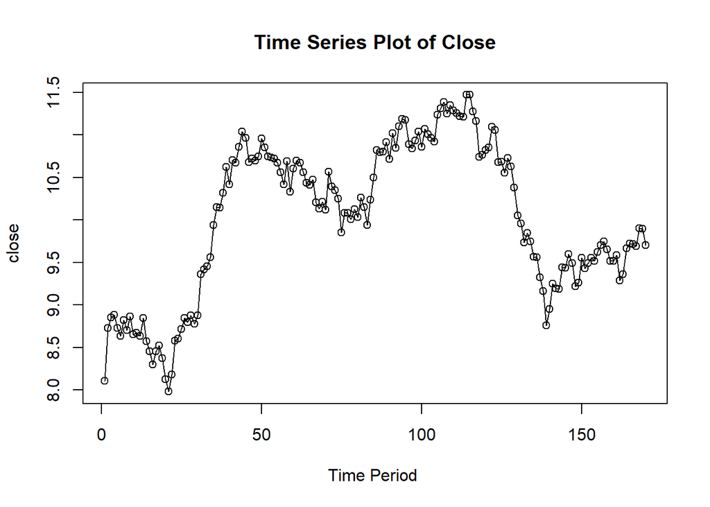

```r
#Membuat plot time series
ts.plot(data.ts, xlab="Time Period ", ylab="close", main= "Time Series Plot of Close")
points(data.ts)
```

#Eksplorasi Data

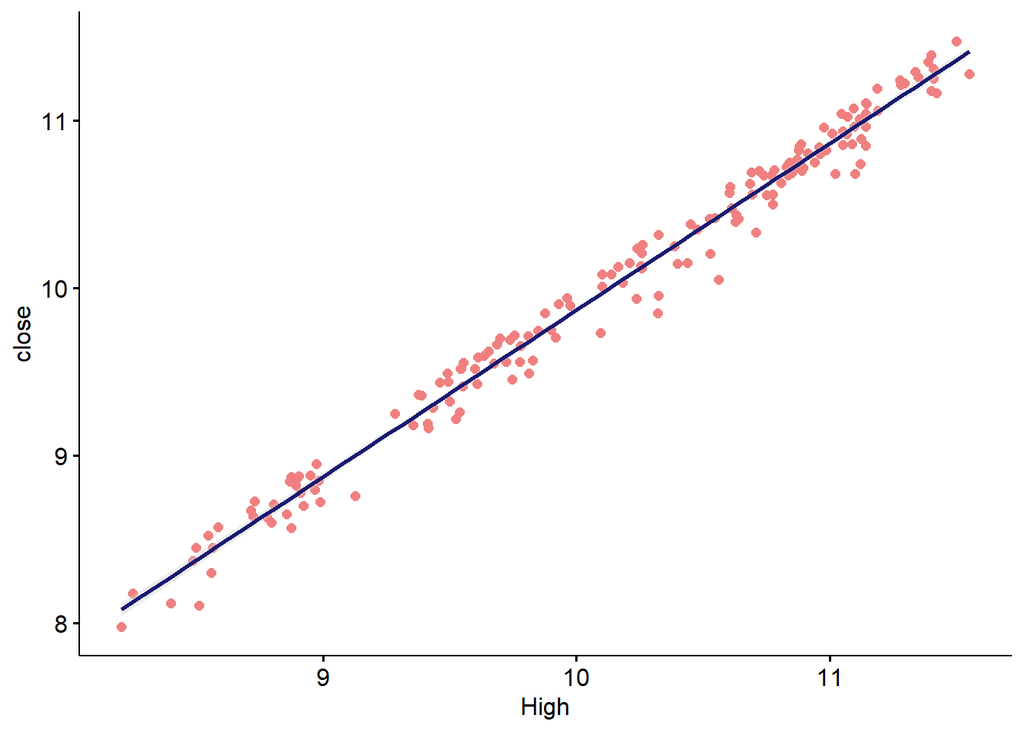

```r
#Eksplorasi Data
library(ggpubr)
ggscatter(data,x = "High",y="close",color="#F08080",
          add = "reg.line" , # Add regression line
          conf.int = TRUE, # Add confidence interval
          add.params = list(color = "#191970",
                            fill = "lightgray"))
```

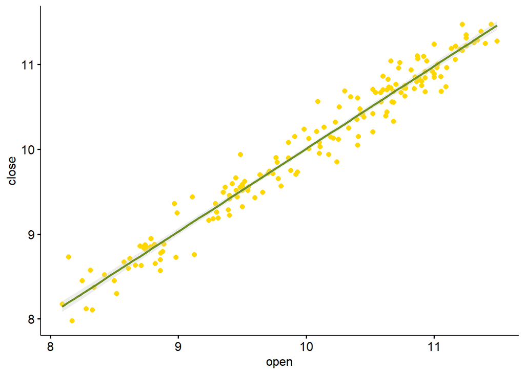

```r
ggscatter(data,x = "open",y="close",color="#FFD700",
          add = "reg.line" , # Add regression line
          conf.int = TRUE, # Add confidence interval
          add.params = list(color = "#6B8E23",
                            fill = "lightgray"))
```

```r
#Berikut adalah Nilai Korelasi
cor(data$High,data$close)
```

```
## [1] 0.992447
```

```r
cor(data$open,data$close)
```

```
## [1] 0.9809984
```

Berdasarkan hasil scatter plot di atas, terlihat adanya hubungan / korelasi positif antara peubah “open” dan “High” terhadap peubah respon yaitu “close”, pada gambar terlihat bahwa titik-titik kedua plot adalah naik ke kanan atas. Hal tersebut didukung dengan hasil perhitungan aplikasi `R` yang menunjukkan nilai korelasi antara “High” dengan “Close” sebesar *0.992447*. Sementara, antara “Open” dengan “Close” memiliki nilai korelasi sebesar *0.9809984*.

```r
#model regresi
model <- lm(close~open+High, data = data)
summary(model)
```

```
##
## Call:
## lm(formula = close ~ open + High, data = data)
##
## Residuals:
##      Min       1Q   Median       3Q      Max
## -0.38224 -0.05380  0.02685  0.08197  0.15325
##
## Coefficients:
##             Estimate Std. Error t value Pr(>|t|)
## (Intercept) -0.10631    0.09546  -1.114  0.26703
## open        -0.19130    0.07181  -2.664  0.00848 **
## High         1.18618    0.07239  16.385  < 2e-16 ***
## ---
## Signif. codes:  0 '***' 0.001 '**' 0.01 '*' 0.05 '.' 0.1 ' ' 1
##
## Residual standard error: 0.1079 on 167 degrees of freedom
## Multiple R-squared:  0.9856, Adjusted R-squared:  0.9854
## F-statistic:  5701 on 2 and 167 DF,  p-value: < 2.2e-16
```

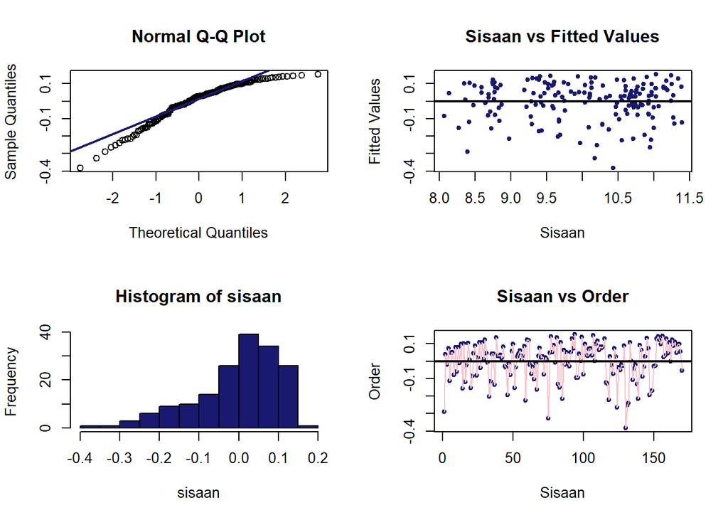

```r
#sisaan dan fitted value
sisaan<- residuals(model)
fitValue<- predict(model)

#Diagnostik dengan eksploratif
par(mfrow = c(2,2))
qqnorm(sisaan)
qqline(sisaan, col = "#191970", lwd = 2)
plot(fitValue, sisaan, col = "#191970", pch = 20, xlab = "Sisaan", ylab = "Fitted Values", main = "Sisaan vs Fitted Values")
abline(a = 0, b = 0, lwd = 2)


hist(sisaan, col = "#191970")
plot(seq(1,170,1), sisaan, col = "#191970", pch = 20, xlab = "Sisaan", ylab = "Order", main = "Sisaan vs Order")
lines(seq(1,170,1), sisaan, col = "#FFC0CB")
 abline(a = 0, b = 0, lwd = 2)
```

Berdasarkan plot yang dihasilkan, pada plot di sebelah kiri menunjukkan apakah sisaan menyebar normal, lalu sebelah kanan menunjukkan sebaran autokorelasi.